# Quarto UKDRI Theme

Inspired by the [R-Ladies theme](https://github.com/beatrizmilz/quarto-rladies-theme)

[Gabriel Mateus Bernardo Harrington](https://gmbernardoharrington.netlify.app/)

Research Associate | Williams Group

2022-10-30

## Example slide

Here is some text. The font is Arial (hex: #00326e). Here is another sentence with **bold** and *italic* text. Here is an example reference: (Baker and Escott-Price 2020)

- Here is a bullet point
- The font used is Arial and font size is 18px
- Bullets are coloured hex: #0ac8ff

[figure not shown]

## Inverted example slide

Here is some text. The font is Arial (hex: #00326e). Here is another sentence with **bold** and *italic* text. Here is an example reference: (Baker and Escott-Price 2020)

- Here is a bullet point
- The font used is Arial and font size is 18px
- Bullets are coloured hex: #0ac8ff

[figure not shown]

## Tabset example

- Example 1
- Example 2

Content here for tabset 1 :)

More content here, for tabset 2 :)

## Incremental content

Hi!

Use `. . .` to separate content as an incremental slide!

## Examples with R code: Plots

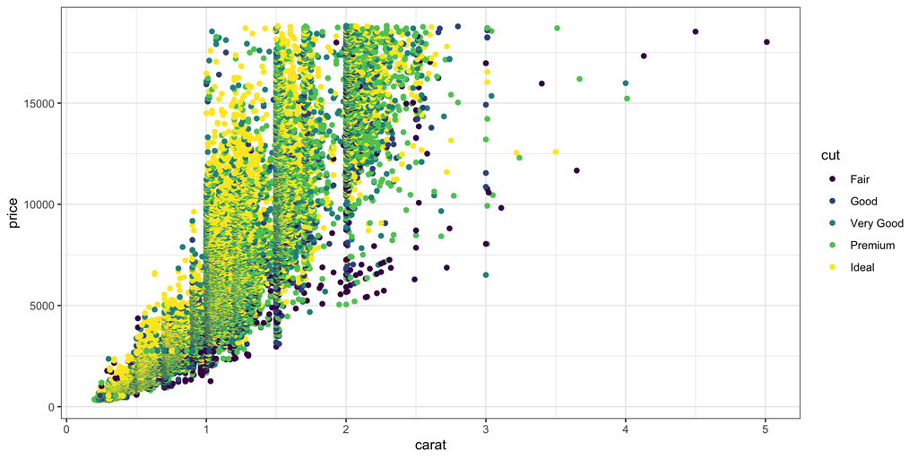

```r
## make a plot
ggplot(diamonds, aes(carat, price, colour = cut)) +
  geom_point() +
  theme_bw() +
  scale_color_viridis_d()
```

## Examples with R code: Tables

```r
## print table
diamonds %>%
  slice_sample(n = 10) %>%
  gt() %>%
  tab_header(title = md("**Table title**"), subtitle = md("A *subtitle*")) %>%
  tab_source_note("Here is some source information")
```

**Table title**

A *subtitle*

| carat | cut | color | clarity | depth | table | price | x | y | z |
| --- | --- | --- | --- | --- | --- | --- | --- | --- | --- |
| 0.34 | Very Good | F | VS2 | 61.5 | 58.2 | 730 | 4.49 | 4.51 | 2.77 |
| 0.51 | Premium | E | SI1 | 58.8 | 58.0 | 1443 | 5.28 | 5.23 | 3.09 |
| 0.32 | Good | J | SI1 | 63.2 | 56.0 | 374 | 4.31 | 4.36 | 2.74 |
| 1.00 | Fair | H | SI2 | 66.1 | 59.0 | 3472 | 6.18 | 6.13 | 4.07 |
| 0.60 | Ideal | D | VVS1 | 62.5 | 55.0 | 4172 | 5.40 | 5.42 | 3.38 |
| 1.27 | Premium | I | SI1 | 60.9 | 59.0 | 5690 | 6.99 | 6.94 | 4.24 |
| 0.51 | Premium | F | VS2 | 61.0 | 58.0 | 1687 | 5.17 | 5.10 | 3.13 |
| 0.34 | Very Good | E | VVS1 | 61.7 | 58.0 | 1014 | 4.43 | 4.48 | 2.75 |
| 0.71 | Very Good | D | VS1 | 63.4 | 55.0 | 2841 | 5.69 | 5.61 | 3.58 |
| 0.53 | Very Good | D | SI1 | 61.4 | 57.0 | 1631 | 5.20 | 5.26 | 3.21 |

Here is some source information

## Examples with R code: HTML Widgets

```r
leaflet() %>%
  addTiles() %>%
  setView(-0.1371784166832623, 51.52405283300594, zoom = 17)
```

[interactive chart not shown]

## Examples with R code: HTML Widgets 2

```r
DT::datatable(
  head(iris, 10),
  fillContainer = FALSE,
  options = list(pageLength = 6)
)
```

|  | Sepal.Length | Sepal.Width | Petal.Length | Petal.Width | Species |
| --- | --- | --- | --- | --- | --- |
| 1 | 5.1 | 3.5 | 1.4 | 0.2 | setosa |
| 2 | 4.9 | 3 | 1.4 | 0.2 | setosa |
| 3 | 4.7 | 3.2 | 1.3 | 0.2 | setosa |
| 4 | 4.6 | 3.1 | 1.5 | 0.2 | setosa |
| 5 | 5 | 3.6 | 1.4 | 0.2 | setosa |
| 6 | 5.4 | 3.9 | 1.7 | 0.4 | setosa |
| 7 | 4.6 | 3.4 | 1.4 | 0.3 | setosa |
| 8 | 5 | 3.4 | 1.5 | 0.2 | setosa |
| 9 | 4.4 | 2.9 | 1.4 | 0.2 | setosa |
| 10 | 4.9 | 3.1 | 1.5 | 0.1 | setosa |

## Example with R code: Math expressions

You can write LaTeX math expressions inside a pair of dollar signs, e.g. `$\alpha+\beta$` renders $\alpha+\beta$. You can use the display style with double dollar signs:

```
$$\bar{X}=\frac{1}{n}\sum_{i=1}^nX_i$$
```

$$\bar{X}=\frac{1}{n}\sum_{i=1}^nX_i$$

## Diagrams with Mermaid!

Read about how to create a diagram in this [post by Mine Çetinkaya-Rundel](https://mine-cetinkaya-rundel.github.io/quarto-tip-a-day/posts/21-diagrams/).

```
flowchart LR
  A[qmd] --> B(Knitr)
  A[qmd] --> C(Jupyter)
  B(Knitr) --> D[md]
  C(Jupyter) --> D[md]
  D[md] --> E(pandoc)
  E(pandoc) --> F(HTML)
  E(pandoc) --> G(PDF)
  E(pandoc) --> H(Word)
  E(pandoc) --> I{and more}
```

Figure 1: How Quarto orchestrates rendering of documents: start with a qmd file, use the Knitr or Jupyter engine to perform the computations and convert it to an md file, then use Pandoc to convert to various file formats including HTML, PDF, and Word.

## Exporting into PDF

You can use the function `pagedown::chrome_print()` to print the HTML version into a PDF!

```r
pagedown::chrome_print("path-to-file.html")
```

## Thanks for listening

[figure not shown]

[figure not shown]

[figure not shown]

## References

Baker, Emily, and Valentina Escott-Price. 2020. “Polygenic Risk Scores in Alzheimer’s Disease: Current Applications and Future Directions.” *Frontiers in Digital Health* 2: 14. https://doi.org/10.3389/fdgth.2020.00014.

Cheng, Joe, Barret Schloerke, Bhaskar Karambelkar, Yihui Xie, and Garrick Aden-Buie. 2025. *Leaflet: Create Interactive Web Maps with the JavaScript Leaflet Library*. https://rstudio.github.io/leaflet/.

Iannone, Richard, Joe Cheng, Barret Schloerke, Ellis Hughes, Alexandra Lauer, JooYoung Seo, Ken Brevoort, and Olivier Roy. 2025. *Gt: Easily Create Presentation-Ready Display Tables*. https://gt.rstudio.com.

Wickham, Hadley. 2023. *Tidyverse: Easily Install and Load the Tidyverse*. https://tidyverse.tidyverse.org.

Wickham, Hadley, Mara Averick, Jennifer Bryan, Winston Chang, Lucy D’Agostino McGowan, Romain François, Garrett Grolemund, et al. 2019. “Welcome to the tidyverse.” *Journal of Open Source Software* 4 (43): 1686. https://doi.org/10.21105/joss.01686.

Xie, Yihui, Joe Cheng, Xianying Tan, and Garrick Aden-Buie. 2025. *DT: A Wrapper of the JavaScript Library DataTables*. https://github.com/rstudio/DT.